# Assessing the impact of a symptom-based mass screening and testing intervention during a novel infectious disease outbreak: The case of COVID-19

27 February, 2020

A symptom-based mass screening and testing intervention (MSTI) can identify a large fraction of infected individuals during an infectious disease outbreak. China is currently using this strategy for the COVID-19 outbreak. However, MSTI might lead to increased transmission if not properly implemented. We investigate under which conditions MSTI is beneficial.

We consider a scenario where a novel pathogen has entered a population and causes symptoms that are non-specific and similar to circulating pathogens, e.g., general respiratory symptoms. The default is to ask individuals with symptoms to stay home and follow general precautionary measures. An alternative option is to implement MSTI, which requires testing anyone with symptoms specific for the novel pathogen at a healthcare facility.

At any given time during an outbreak, a proportion, $P$, of those showing symptoms will be infected with the novel pathogen. For symptomatic patients who stay home, the expected number of transmissions of the novel pathogen caused by that person is the average number of transmissions caused by someone who is infected with that pathogen (reproductive number, R), multiplied by the probability the person is infected with the new pathogen, $T_H = RP$. Similarly, such a patient has a mortality risk due to the novel pathogen of $M_H = M P$, where $M$ is the probability of death if a person enters a healthcare facility under regular circumstances, i.e., when they feel bad enough to seek medical care.

For individuals who go through an MSTI, there are two possible scenarios (Figure 1). If the symptomatic individual is infected with the novel pathogen (probability $P$), we assume that they are correctly identified and placed under isolation and treatment, where they have reduced transmission and mortality risks, namely $R_I P$ and $M_I P$. Importantly, if the health system is strained, those patients arriving at the testing facility without being infected with the novel pathogen (probability $1-P$) may become infected by another person in the testing facility. We denote this probability of becoming infected with $F$. Since these individuals test negative, we assume they will be sent home and then have the same transmission and mortality risk as individuals asked to remain at home. Thus, the total transmission potential for a person undergoing screening is $T_S = R_I P + R F (1-P)$ and the total mortality risk is $M_S = M_I P + M F (1-P)$.

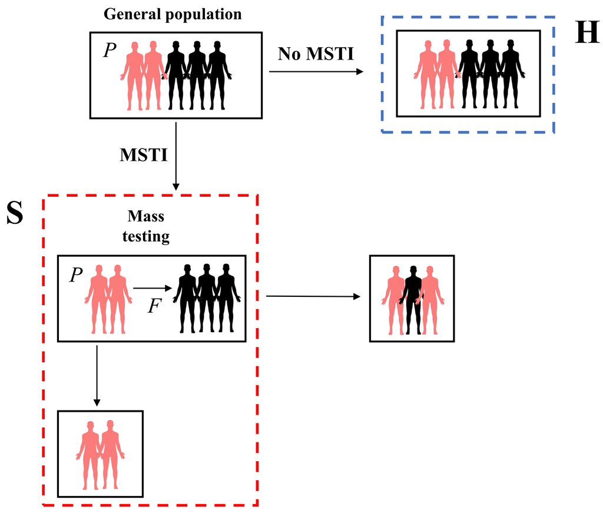

Figure 1: Structure of the model

We can define transmission and mortality risk ratios (TRR and MRR), which are given by $TRR=T_S/T_H = R_I / R + (1-P) F/P$ and $MRR=M_S/M_H= M_I / M_0 + (1-P) F/P$. If that expression is less than 1, it suggests that MSTI reduces transmission and mortality. If it is larger than 1, the better strategy would be to not implement MSTI.

As a best-case scenario, we consider a situation where isolation and treatment following a positive test are perfect, with $R_I = M_I = 0$ (other scenarios are explored in the SM). In that case, TRR and MRR are the same and given by $(1-P)F/P$. To keep this ratio below 1, the risk of MSTI associated infection needs to be $F<P/(1-P)$.

Figure 2 shows a heatmap for TRR or MRR (on a log scale) for different values of $F$ and $P$. The solid line is given by $F=P/(1-P)$, at which TRR/MRR=1 (thus their log is 0). This line marks the threshold at which MSTI changes from being beneficial to not being beneficial.

For small $P$, this is essentially a linear relationship, $F \approx P$. This means that if the fraction of those infected with the novel pathogen among those with symptoms is low, MSTI is only suitable if the risk of infection associated with MSTI is less than the fraction of symptomatic who carry the novel pathogen. $P$ will be low if the overall pathogen prevalence is low (e.g. early in an outbreak) and if symptoms are so broad that only a small fraction of those individuals with symptoms are infected with the novel pathogen. As $P$ increases, a larger MSTI associated infection risk is acceptable. Once $P$ reaches a value of $\ge 0.5$, MSTI becomes useful even if $F=1$, i.e. MSTI associated infection is certain. If such a high $P$ is reached because the novel pathogen is widespread, MSTI is likely logistically unfeasible. If instead a high $P$ can be reached by better discrimination of symptoms, MSTI can be a useful strategy.

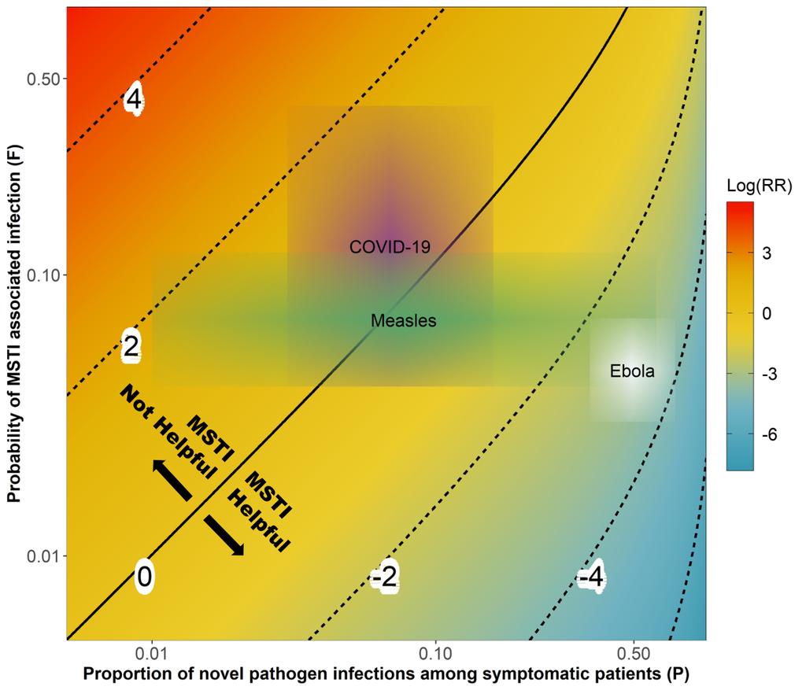

Figure 2: Transmission and mortality risk ratio (log scale) as function of novel pathogen prevalence among individuals showing symptoms, $P$, and testing-site related infection risk factor, $F$. For TRR/MRR the threshold at which MSTI becomes beneficial is 1, thus for the log shown here this threshold is 0. Everything below this threshold indicates that MSTI is helpful, above 0 it is not. Indicated in color are estimates for $P$ and $F$ ranges for 3 different pathogens (see SM for details).

While hard numbers for the quantities $F$ and $P$ for specific pathogens or outbreaks are impossible to obtain, we used previously published data to obtain very rough estimates for $F$ and $P$ ranges for the COVID-19 outbreak, as well as the 2014 Ebola outbreak and a combination of previous measles outbreaks (see SM for details). Those estimates are shown as colored areas in the figure. For both measles and COVID-19, our estimates suggest that depending on the specific setting (e.g. a specific country), MSTI might or might not be beneficial. It seems more clearly beneficial for Ebola, mainly due to Ebola-related symptoms that make the disease easier to discriminate from other pathogens, thus leading to a higher $P$.

For MSTI to be beneficial, one needs to minimize $F$ and maximize $P$. An approach to reduce $F$ could be the use of dedicated testing sites separate from the usual healthcare facilities. Staff at those sites can be trained to follow protocols that reduce transmission risk. One could also ask symptomatic individuals to call a phone number and schedule a test, instead of allowing individuals to self-report at any time. With a scheduling system, crowding can be reduced, and when individuals show up at the scheduled time, they can be processed rapidly, thus reducing transmission risk.

$P$ can be increased by having a more specific case definition (ideally without losing sensitivity). This would reduce the overall pool of individuals with symptoms and increases $P$ among those targeted for testing. More refined case definitions, screening by experts using telemedicine approaches, or rapid home tests could all be options which reduce the pool of those considered at risk of being infected with the novel pathogen, thus increasing $P$. This will also reduce the total number of individuals going to testing sites, likely reducing $F$.

Overall, our analysis suggests that MSTI can be useful if the probability of transmission at testing sites is less than the probability that a symptomatic person is infected with the novel pathogen. Both $F$ and $P$ will likely vary between settings and thus should be evaluated for a specific setting, e.g. a specific country, if MSTI is considered as a potential control strategy.

**For more detailed information please see** [**the Pre-Print version**](https://www.medrxiv.org/content/10.1101/2020.02.20.20025973v1)

中文题目: 评估基于症状特征的广泛筛查和检测对于不明原因传染病爆发的控制效果： COVID-19 冠状病毒疫情的推演

中文摘要: 为控制COVID-19疫情，中国尤其是武汉地区正对于特定人群开展基于症状特征的广泛筛查和检测（MSTI）。通常这种主动的病例筛查措施能够及时且较完整的发现潜在的感染病例从而起到对控制疫情的正面效果。由于COVID-19有一定可能性在全球多个国家爆发或者传播，可以预见的是这种病例筛查措施有可能也会被其他国家采纳为防控措施之一。然而在实施MSTI过程中，交叉暴露与院内感染的风险会使新病例的产生成为可能，从而使得MSTI对于疫情控制的实际效果将不独立于外部条件。在本研究中我们通过不同的情景假设对于MSTI的防控效果进行了评价。

在COVID-19的疫情初期，MSTI的筛查与检测通常在非医疗机构由非医疗人员通过测量额温和其他症状（例如：咳嗽，乏力等）发现疑似病例，然后送至指定医疗机构（例如：发热门诊）进行相关医学检测。我们考虑到这样的干预措施由于缺乏一定的特异性，在爆发的初期，疑似病例中会有相当比例的非COVID-19病原感染者（例如：细菌性肺炎，其他类型流感等）。因此在某些条件下，MSTI可能会事与愿违的在当地产生更多新的病例，对其他病患造成更高的死亡风险。通过概率模型的推演，我们发现当医疗机构检测地点中病原感染者的比例（P）低于交叉感染的可能性（F）时，执行MSTI产生的新病例与死亡风险高于未执行MSTI时的风险（图1）。我们将这个模型运用于现有的一些关于COVID-19，麻疹与埃博拉疫情的数据后发现，MSTI通常对于埃博拉具有较好的控制效果，对于麻疹和COVID-19的控制效果存在不确定性。在某些条件下，MSTI可能会对疫情的控制起到负面的效果。

当COVID-19感染比例较低（P），且交叉感染的可能性（F）较高时，MSTI可能会对疫情的控制起到负面效果。